# The case for more GIS in front-line diplomacy

|| **0.0|READ ME** || 1.0|EXTRACT || 2.0|TRANSFORM || 3.0|LOAD and ANALYSE ||

### 0.0 Read me

> **Purpose of section**: brief outline of document, its content and pre-requisits  
> **Inputs**: none  
> **Outputs**: none

#### 0.1 Outline of document

This notebook outlines the *process* and *code* outputs associated with a project on the role of GIS in international relations and diplomacy academia and practice.

#### 0.2 Document index

0. Read me
   - || 0.1-Outline || 0.2-Index || 0.3-Setup ||
1. Extract
   - || 1.1-Load || 1.2-Tidy || 1.3-Summarise ||
2. Transform
   - || 2.1-Reload data || 2.2-ISO encoding || 2.3-Geocoding ||
3. Load and analyse
   - || 3.1-Load and segment data frame || 3.2-Define visualisation function || 3.3-Visualise 1.0 || 3.4-Visualise 2.0, clustering and outlier removal ||
- Reference code section

#### 0.3 Pre-requisites and set up

In order for the code below to work, please ensure you have installed and loaded the relevant packages.

```r
#Installing packages (uncomment as required)
#install.packages(c("countrycode","tidyverse","sf","mapview","ggmap"))

library(countrycode) #iso tagging of countries
library(tidyverse) #number of packages for data manipulation, specifically want readr, dplyr, tibble
library(sf) #creation of spatial objects
library(mapview) #mapping package
library(ggmap) #for google api access
```

Set parameters for the entire workflow

```r
#Set this to TRUE or FALSE to determine whether to use local, pre-loaded files or refresh via relevant API, i.e. (Google/ACLED) connections.
use_local_files <- TRUE
```

|| 0.0|READ ME || **1.0|EXTRACT** || 2.0|TRANSFORM || 3.0|LOAD and ANALYSE ||

### 1.0 Extract Lowy Institute data

**Note** on downloading from the Lowy Institute site, there may be incompatibility with downloads in Safari, chrome is recommended, have not tested other browsers.

#### 1.1 Load .csv file and check data types

```r
###Confirm working directory
print(getwd())
```

```
## [1] "/cloud/project/R_Notebook/Final"
```

```r
###open latest csv document based on relative path
lowy_raw_data <- read.csv("./Data/Raw_data/2019_LowyInstituteGlobalDiplomacyIndex_FullDataset.csv")
```

#### 1.2 Tidy up dataset

**Check for**: factors; rename columns; seperate out relevant columns  
**Output**:

1. renamed data frame `lowy_renamed`
2. other meta data `lowy_meta`
3. ranking data `lowy_rank`
4. **posting data** `lowy_posting` **<===** this is the relevant one for the rest of the work

```r
###check for factor columns and change them to character columns
#more of a pre-emptive measure
i <- sapply(lowy_raw_data, is.factor)
lowy_raw_data[i] <- lapply(lowy_raw_data[i], as.character)

###column rename
#new data frame (a)
lowy_renamed <- lowy_raw_data

#rename columns
lowy_renamed <- lowy_renamed %>% dplyr::rename(
  send_country=COUNTRY,
  #metadata
  meta_gdp_usd_billions = GDP..B..USD.,
  meta_population_millions = POPULATION..M.,
  #ranking columns
  rank_g20 = G20.RANK,
  rank_OECD = OECD.RANK,
  rank_asia = ASIA.RANK,
  rank_overall = OVERALL.RANK,
  #post country info
  post_city = POST.CITY,
  post_country = POST.COUNTRY,
  post_type = TYPE.OF.POST,
  post_title = POST.TYPE.TITLE
  )

#data frame with all metadata (GDP and population) (b)
lowy_meta <- lowy_renamed[, c("send_country","meta_population_millions","meta_gdp_usd_billions")]

#data frame with all rankings (G20, OECD, Asia and overall) (c)
lowy_rank <- lowy_renamed[,c("send_country","rank_g20","rank_OECD","rank_asia","rank_overall")]

#data frame with information on sending country, post city, country as well as post type and title (d)
lowy_posting <- lowy_renamed[,c("send_country","post_city","post_country","post_type","post_title")]

###save data frames as .csv files ready for part 2
write.csv(lowy_posting,"./Data/Processing/Part_1_Out_Lowy_Posting.csv", row.names = FALSE)
write.csv(lowy_rank,"./Data/Processing/Part_1_Out_Lowy_Rank.csv", row.names = FALSE)
write.csv(lowy_meta,"./Data/Processing/Part_1_Out_Lowy_Meta.csv", row.names = FALSE)

#quick preview of data frame to work on
head(lowy_posting,2)
```

```
##   send_country post_city post_country                 post_type post_title
## 1    Argentina   Algiers      Algeria Embassy / High Commission    Embassy
## 2    Argentina    Luanda       Angola Embassy / High Commission    Embassy
```

#### 1.3 Raw key information

Warning: an error may appear when running

```r
###report all unique values/entries
#Summarise all unique values in crude print out
for(column in colnames(lowy_posting)){
  cat(column,"has",length(apply(lowy_posting[column],2,unique)),"unique values\n")
}
```

```
## send_country has 61 unique values
## post_city has 686 unique values
## post_country has 207 unique values
## post_type has 4 unique values
## post_title has 141 unique values
```

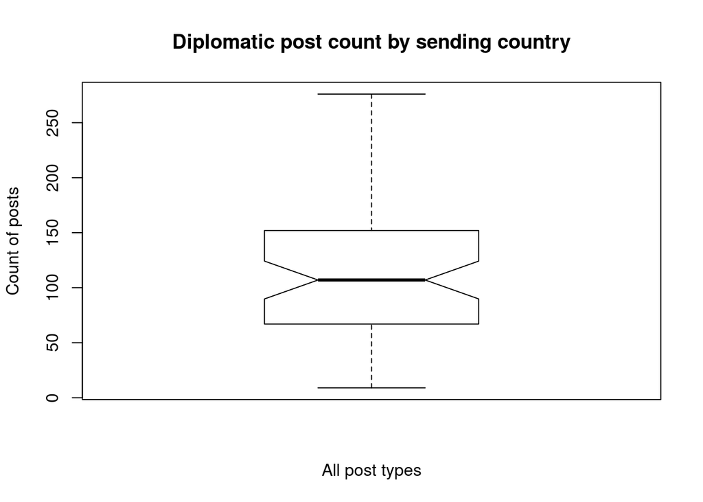

```r
###summary stats
lowy_type_table <- ftable(table(lowy_posting$send_country,lowy_posting$post_type))

###summarise count by send country
lowy_count_per_send_country <- lowy_posting %>%
  group_by(send_country) %>%
  summarise(count = n()) %>%
  arrange(desc(count))

per_country_count <- lowy_count_per_send_country$count

per_country_box <- boxplot(data=per_country_count, x=per_country_count, main="Diplomatic post count by sending country",
   xlab="All post types", ylab="Count of posts",notch = TRUE)
```

```r
cat("Per country count summary",
    "\nMin value:",per_country_box$stats[1,1],
    "\n25th percentile:",per_country_box$stats[2,1],
    "\nMedian value:",per_country_box$stats[3,1],
    "\n75th percentile:",per_country_box$stats[4,1],
    "\nMax value:",per_country_box$stats[5,1]
    )
```

```
## Per country count summary
## Min value: 9
## 25th percentile: 67
## Median value: 107
## 75th percentile: 152
## Max value: 276
```

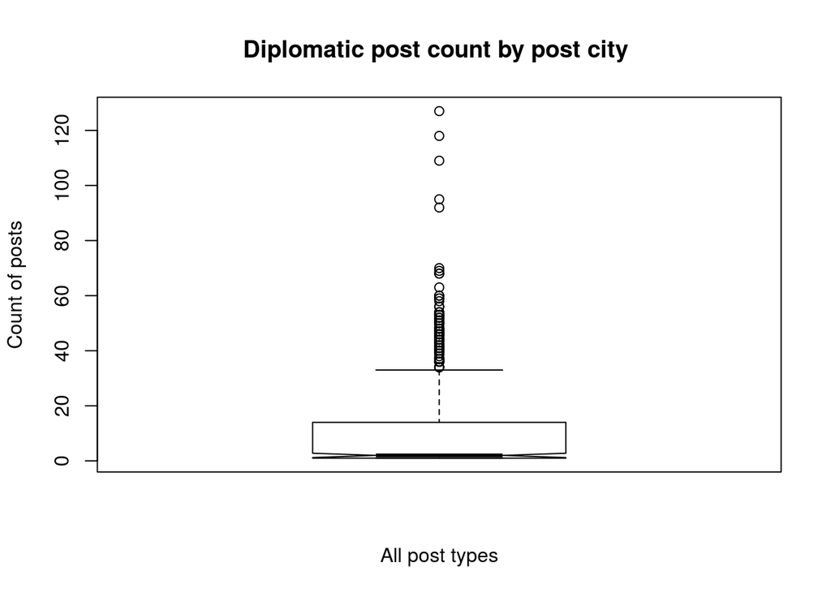

```r
###summarise count by post city
lowy_count_per_post_city <- lowy_posting %>%
  group_by(post_city) %>%
  summarise(count = n()) %>%
  arrange(desc(count))

per_post_city_count <- lowy_count_per_post_city$count

per_post_city_box <- boxplot(data=per_post_city_count, x=per_post_city_count, main="Diplomatic post count by post city ",
   xlab="All post types", ylab="Count of posts",notch = TRUE)
```

```r
cat("Per post city count summary",
    "\nMin value:",per_post_city_box$stats[1,1],
    "\n25th percentile:",per_post_city_box$stats[2,1],
    "\nMedian value:",per_post_city_box$stats[3,1],
    "\n75th percentile:",per_post_city_box$stats[4,1],
    "\nMax value:",per_post_city_box$stats[5,1]
    )
```

```
## Per post city count summary
## Min value: 1
## 25th percentile: 1
## Median value: 2
## 75th percentile: 14
## Max value: 33
```

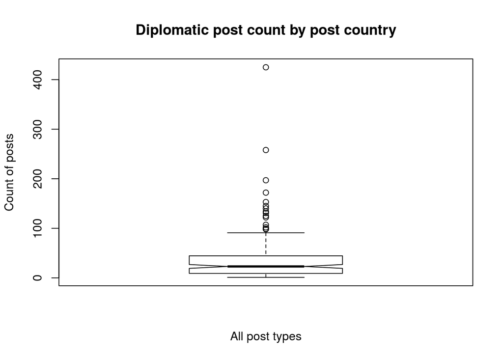

```r
###summarise count by post country
lowy_count_per_post_country <- lowy_posting %>%
  group_by(post_country) %>%
  summarise(count = n()) %>%
  arrange(desc(count))

per_post_country_count <- lowy_count_per_post_country$count

per_post_country_box <- boxplot(data=per_post_country_count, x=per_post_country_count, main="Diplomatic post count by post country",
   xlab="All post types", ylab="Count of posts",notch = TRUE)
```

```r
cat("Per post country count summary",
    "\nMin value:",per_post_city_box$stats[1,1],
    "\n25th percentile:",per_post_city_box$stats[2,1],
    "\nMedian value:",per_post_city_box$stats[3,1],
    "\n75th percentile:",per_post_city_box$stats[4,1],
    "\nMax value:",per_post_city_box$stats[5,1]
    )
```

[output not shown]

|| 0.0|READ ME || 1.0|EXTRACT || **2.0|TRANSFORM** || 3.0|LOAD and ANALYSE ||

### 2.0 Transform Lowy Institute data

#### 2.1 Re-load

```r
lowy_data <- read_csv("./Data/Processing/Part_1_Out_Lowy_Posting.csv")
```

#### 2.2 ISO codes

```r
###Set up

#iso dataframe
lowy_data_iso <- lowy_data

#country_iso list [column 1]
iso_list_send_country <- c()
iso_list_send_country_num <- c()
#post_country_iso list [column 3]
iso_list_post_country <- c()
iso_list_post_country_num <- c()

###ending country column (1) three digit numbers
for(country in lowy_data_iso[1]){
  country_iso <- countrycode(
    #call the entry of 'Country' for the row_number currently being taken by for loop
    sourcevar = country,
    #three letter iso code
    destination = "iso3n",
    #based on english language names
    origin = "country.name")

  #add value to a list
  iso_list_send_country_num <- append(iso_list_send_country_num,country_iso)
}

###sending country column (1) three digit letters
for(country in lowy_data_iso[1]){
  country_iso <- countrycode(
    #call the entry of 'Country' for the row_number currently being taken by for loop
    sourcevar = country,
    #three letter iso code
    destination = "genc3c",
    #based on english language names
    origin = "country.name")

  #add value to a list
  iso_list_send_country <- append(iso_list_send_country,country_iso)
}
#===================================
###Post country column (3) three digit numbers
for(country in lowy_data_iso[3]){
  post_country_iso <- countrycode(
    #call the entry of 'Country' for the row_number currently being taken by for loop
    sourcevar = country,
    #three letter iso code
    destination = "iso3n",
    #based on english language names
    origin = "country.name")

  #add value to a list
  iso_list_post_country_num <- append(iso_list_post_country_num,post_country_iso)
}
###Post country column (3) three letters
for(country in lowy_data_iso[3]){
  post_country_iso <- countrycode(
    #call the entry of 'Country' for the row_number currently being taken by for loop
    sourcevar = country,
    #three letter iso code
    destination = "genc3c",
    #based on english language names
    origin = "country.name")

  #add value to a list
  iso_list_post_country <- append(iso_list_post_country,post_country_iso)
}
###create new columns
lowy_data_iso$send_country_iso = iso_list_send_country
lowy_data_iso$send_country_iso_num = iso_list_send_country_num

lowy_data_iso$post_country_iso = iso_list_post_country
lowy_data_iso$post_country_iso_num = iso_list_post_country_num

###preview data frame
head(lowy_data_iso,3)
```

```
## # A tibble: 3 x 9
##   send_country post_city post_country post_type post_title send_country_iso
##   <chr>        <chr>     <chr>        <chr>     <chr>      <chr>
## 1 Argentina    Algiers   Algeria      Embassy … Embassy    ARG
## 2 Argentina    Luanda    Angola       Embassy … Embassy    ARG
## 3 Argentina    Yerevan   Armenia      Embassy … Embassy    ARG
## # … with 3 more variables: send_country_iso_num <int>, post_country_iso <chr>,
## #   post_country_iso_num <int>
```

#### 2.3 Geo-coding

This section requires a google api key; you can set one up [here](https://console.cloud.google.com/) through the google cloud platform

```r
register_google(key = "AIzaSyDNlUg_mclZ4kSJMDvbj_UVMHds8vkz2nE")
```

Code to run the geocoding for each country column (`send_country` `post_country`), city `post_city` + `post country` (to avoid finding wrong city)

**Part 1 cities and countries**

```r
###========Preparation

###concatenate post city and post country columns
lowy_data_iso$post_city_country = paste(
  lowy_data_iso$post_city,
  lowy_data_iso$post_country,
  sep=", ")

###geo-c - concatenated city and country names
geo_city_country <- distinct(lowy_data_iso,post_city_country)
geo_city_country_df <- as.data.frame(geo_city_country)
#geo_city_country_df <- head(geo_city_country_df,4) #for sample work only

###geo-code - sending countries
geo_send_country <- distinct(lowy_data_iso,send_country)
geo_send_country_df <- as.data.frame(geo_send_country)
#geo_send_country_df <- head(geo_send_country_df,4) #for sample work only

###========POST CITIES
#if local file tag is set to TRUE, google api will not be used
if(use_local_files) {
  print("Local file flag set to TRUE, using local files")
  geo_city_country_df_dl <- read.csv("./Data/GoogleAPI/Geo_City_Country_DL.csv")
} else {
  print("Local file flag set to FALSE, calling google now!")
  geo_city_country_df_dl <- mutate_geocode(geo_city_country_df, post_city_country)
  #Save .csv file
  write.csv(geo_city_country_df_dl,"./Data/GoogleAPI/Geo_City_Country_DL.csv", row.names = FALSE)
}
```

```
## [1] "Local file flag set to TRUE, using local files"
```

```r
###========SEND COUNTRIES
#if local file tag is set to TRUE, google api will not be used
if(use_local_files) {
  print("Local file flag set to TRUE, using local files")
  geo_send_country_df_dl <- read.csv("./Data/GoogleAPI/Geo_Send_Country_DL.csv")
} else {
  print("Local file flag set to FALSE, calling google now!")
  geo_city_country_df_dl <- mutate_geocode(geo_city_country_df, post_city_country)
  #Save .csv file
  write.csv(geo_send_country_df_dl,"./Data/GoogleAPI/Geo_Send_Country_DL.csv", row.names = FALSE)
}
```

```
## [1] "Local file flag set to TRUE, using local files"
```

```r
###========VIEW DATAFRAMES
head(geo_city_country_df_dl,3)
```

```
##   post_city_country       lon       lat
## 1  Algiers, Algeria  3.058756 36.753768
## 2    Luanda, Angola 13.230176 -8.814656
## 3  Yerevan, Armenia 44.515209 40.187202
```

```r
head(geo_send_country_df_dl,3)
```

```
##   X send_country       lon       lat
## 1 1    Argentina -63.61667 -38.41610
## 2 2    Australia 133.77514 -25.27440
## 3 3      Austria  14.55007  47.51623
```

```r
###========JOIN DATA TO MASTER DATA FRAME
lowy_data_geo <- lowy_data_iso

#Join send lon/lat
lowy_data_geo <- merge(lowy_data_geo,geo_send_country_df_dl, by = "send_country")

lowy_data_geo <- lowy_data_geo %>% rename(
  send_lon =lon,
  send_lat = lat)

head(lowy_data_geo)
```

```
##   send_country post_city post_country                 post_type post_title
## 1    Argentina   Algiers      Algeria Embassy / High Commission    Embassy
## 2    Argentina    Luanda       Angola Embassy / High Commission    Embassy
## 3    Argentina   Yerevan      Armenia Embassy / High Commission    Embassy
## 4    Argentina  Canberra    Australia Embassy / High Commission    Embassy
## 5    Argentina    Vienna      Austria Embassy / High Commission    Embassy
## 6    Argentina      Baku   Azerbaijan Embassy / High Commission    Embassy
##   send_country_iso send_country_iso_num post_country_iso post_country_iso_num
## 1              ARG                   32              DZA                   12
## 2              ARG                   32              AGO                   24
## 3              ARG                   32              ARM                   51
## 4              ARG                   32              AUS                   36
## 5              ARG                   32              AUT                   40
## 6              ARG                   32              AZE                   31
##     post_city_country X  send_lon send_lat
## 1    Algiers, Algeria 1 -63.61667 -38.4161
## 2      Luanda, Angola 1 -63.61667 -38.4161
## 3    Yerevan, Armenia 1 -63.61667 -38.4161
## 4 Canberra, Australia 1 -63.61667 -38.4161
## 5     Vienna, Austria 1 -63.61667 -38.4161
## 6    Baku, Azerbaijan 1 -63.61667 -38.4161
```

```r
#Join post city lon/lat
lowy_data_geo <- merge(lowy_data_geo,geo_city_country_df_dl, by = "post_city_country")

lowy_data_geo <- lowy_data_geo %>% rename(
  post_city_lon =lon,
  post_city_lat = lat)

head(lowy_data_geo)
```

```
##        post_city_country   send_country post_city  post_country
## 1 Abidjan, Cote d'Ivoire         Israel   Abidjan Cote d'Ivoire
## 2 Abidjan, Cote d'Ivoire United Kingdom   Abidjan Cote d'Ivoire
## 3 Abidjan, Cote d'Ivoire          Japan   Abidjan Cote d'Ivoire
## 4 Abidjan, Cote d'Ivoire          China   Abidjan Cote d'Ivoire
## 5 Abidjan, Cote d'Ivoire    Netherlands   Abidjan Cote d'Ivoire
## 6 Abidjan, Cote d'Ivoire        Germany   Abidjan Cote d'Ivoire
##                   post_type post_title send_country_iso send_country_iso_num
## 1 Embassy / High Commission    Embassy              ISR                  376
## 2 Embassy / High Commission    Embassy              GBR                  826
## 3 Embassy / High Commission    Embassy              JPN                  392
## 4 Embassy / High Commission    Embassy              CHN                  156
## 5 Embassy / High Commission    Embassy              NLD                  528
## 6 Embassy / High Commission    Embassy              DEU                  276
##   post_country_iso post_country_iso_num  X   send_lon send_lat post_city_lon
## 1              CIV                  384 25  34.851612 31.04605     -4.008256
## 2              CIV                  384 59  -3.435973 55.37805     -4.008256
## 3              CIV                  384 27 138.252924 36.20482     -4.008256
## 4              CIV                  384 12 104.195397 35.86166     -4.008256
## 5              CIV                  384 39   5.291266 52.13263     -4.008256
## 6              CIV                  384 18  10.451526 51.16569     -4.008256
##   post_city_lat
## 1      5.359952
## 2      5.359952
## 3      5.359952
## 4      5.359952
## 5      5.359952
## 6      5.359952
```

**Part 2 exact embassy locations**  
Code to run the geocoding for exact embassy locations. Using combination of `send_country`+`post_country`+“Embassy”+ `post_city`

```r
###master dataframe with all data
lowy_data_geo_master <- lowy_data_geo

###Exact geocoding query
lowy_data_geo_master$full_geo_query = paste(
  lowy_data_geo_master$send_country,
  lowy_data_geo_master$post_title,
  lowy_data_geo_master$post_city_country,
  sep=", ")

###RUN GEOCODING
if(use_local_files) {
  print("Local file flag set to TRUE, using local files")
  lowy_data_geo_master <- read.csv("./Data/GoogleAPI/lowy_data_geo_master.csv")
} else {
  print("Local file flag set to FALSE, calling google now!")
  lowy_data_geo_master <- mutate_geocode(lowy_data_geo_master, full_geo_query)

  #rename columns
  lowy_data_geo_master <- lowy_data_geo_master %>% rename(
  exact_post_lon = lon,
  exact_post_lat = lat)

  #Save .csv file
  write.csv(geo_send_country_df_dl,"./Data/GoogleAPI/lowy_data_geo_master.csv", row.names = FALSE)
}
```

```
## [1] "Local file flag set to TRUE, using local files"
```

```r
#Unload unnecessary data from global environment
rm(list = ls()) #purge all else (comment/uncomment as needed)
```

|| 0.0|READ ME || 1.0|EXTRACT || 2.0|TRANSFORM || **3.0|LOAD and ANALYSE** ||

### 3.0 Load and analyse Lowy Institute data

> **Purpose of section**: visualise coordinates; and run clustering analysis  
> **Inputs**: `lowy_data_geo_master` (final output of part 2)  
> **Outputs**: maps and visuals

#### 3.1 Load data and segmet usable part for analysis

```r
###Load data from section 2
lowy_data_complete <- read_csv("./Data/GoogleAPI/lowy_data_geo_master.csv")
###Filter out unusable datapoints
#names(lowy_data_complete)

#Re-arrange columns and sort table
lowy_data_complete <-lowy_data_complete
lowy_data_complete = select(lowy_data_complete,
                            #sending data
                            send_country_iso,
                            send_country,
                            send_lon,
                            send_lat,
                            #posting data
                            post_country_iso,
                            post_country,
                            post_city_country,
                            post_city,
                            post_city_lon,
                            post_city_lat,
                            post_type,
                            post_title,
                            #other columns
                            everything())

lowy_data_complete <- lowy_data_complete[order(lowy_data_complete$send_country),]
head(lowy_data_complete)
```

```
## # A tibble: 6 x 15
##   send_country_iso send_country send_lon send_lat post_country_iso post_country
##   <chr>            <chr>           <dbl>    <dbl> <chr>            <chr>
## 1 ARG              Argentina       -63.6    -38.4 ARE              United Arab…
## 2 ARG              Argentina       -63.6    -38.4 NGA              Nigeria
## 3 ARG              Argentina       -63.6    -38.4 ETH              Ethiopia
## 4 ARG              Argentina       -63.6    -38.4 DZA              Algeria
## 5 ARG              Argentina       -63.6    -38.4 TUR              Turkey
## 6 ARG              Argentina       -63.6    -38.4 CHL              Chile
## # … with 9 more variables: post_city_country <chr>, post_city <chr>,
## #   post_city_lon <dbl>, post_city_lat <dbl>, post_type <chr>,
## #   post_title <chr>, full_geo_query <chr>, exact_post_lon <dbl>,
## #   latexact_post_lat <dbl>
```

```r
#Filter out NA values (around 44 values)
geo_lowy_NA_values <- lowy_data_complete %>%
  dplyr::select(everything()) %>%
  dplyr::filter(is.na(exact_post_lon))

geo_lowy_no_NA <- lowy_data_complete %>%
  dplyr::select(everything()) %>%
  dplyr::filter(!is.na(exact_post_lon))

#Preview table
report_full_length <-length(lowy_data_complete$send_country)
report_na_length <- length(geo_lowy_NA_values$send_country)
report_non_na_length <- length(geo_lowy_no_NA$send_country)

cat("There are,", report_full_length,"entries in the complete data frame.","\nFrom these,",report_na_length,"are NA/blank. (",report_na_length/report_full_length*100,"% )","\nIn total,",report_non_na_length,"entries have valid coordinates.","\nTotal coverage is:",report_non_na_length/report_full_length*100,"%")
```

```
## There are, 7317 entries in the complete data frame.
## From these, 44 are NA/blank. ( 0.6013393 % )
## In total, 7273 entries have valid coordinates.
## Total coverage is: 99.39866 %
```

#### 3.2 Geo-coding analysis function

Function to take in data frame, and a filter to visualise and return filtered dataframe for further analysis `f_exact_city_postings <- function(p_city_filter,p_df){}` see code here for further details

#### 3.3 Visualise

Run function on array of cities of interest

```r
###run function
f_out <- f_exact_city_postings(p_city_filter = "Tehran",p_df = geo_lowy_no_NA)
f_out$map
```

[interactive chart not shown]

#### 3.4 Clustering

Use function output from 3.3 to run DBSCAN spatial clustering analysis

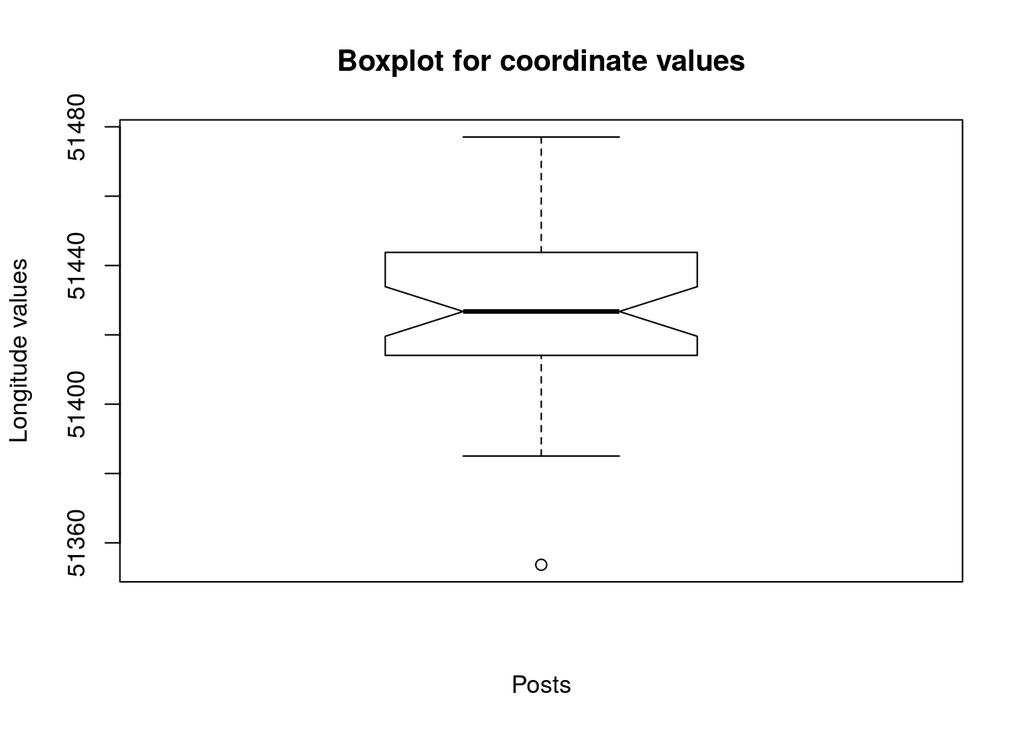

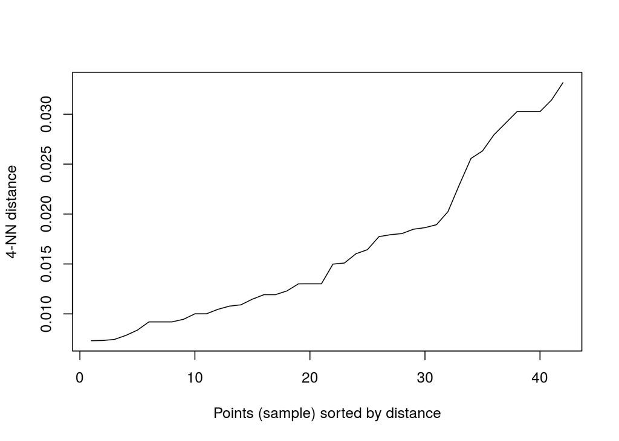

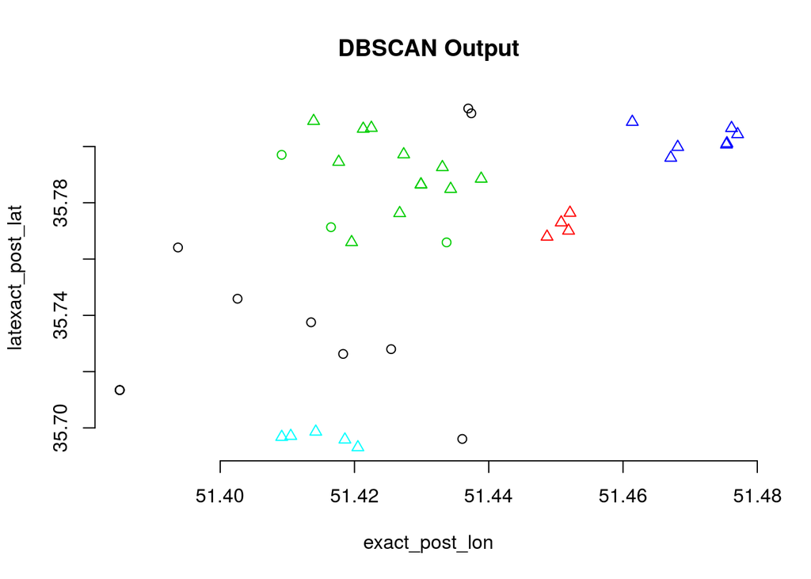

```
## $df_sub
## # A tibble: 43 x 15
##    send_country_iso send_country send_lon send_lat post_country_iso post_country
##    <chr>            <chr>           <dbl>    <dbl> <chr>            <chr>
##  1 ARG              Argentina      -63.6    -38.4  IRN              Iran Islami…
##  2 AUS              Australia      134.     -25.3  IRN              Iran Islami…
##  3 AUT              Austria         14.6     47.5  IRN              Iran Islami…
##  4 BGD              Bangladesh      90.4     23.7  IRN              Iran Islami…
##  5 BEL              Belgium          4.47    50.5  IRN              Iran Islami…
##  6 BRA              Brazil         -51.9    -14.2  IRN              Iran Islami…
##  7 BRN              Brunei Daru…   115.       4.54 IRN              Iran Islami…
##  8 CHN              China          104.      35.9  IRN              Iran Islami…
##  9 CZE              Czech Repub…    15.5     49.8  IRN              Iran Islami…
## 10 DNK              Denmark          9.50    56.3  IRN              Iran Islami…
## # … with 33 more rows, and 9 more variables: post_city_country <chr>,
## #   post_city <chr>, post_city_lon <dbl>, post_city_lat <dbl>, post_type <chr>,
## #   post_title <chr>, full_geo_query <chr>, exact_post_lon <dbl>,
## #   latexact_post_lat <dbl>
##
## $map
##
## $box_plot
## $box_plot$stats
##          [,1]
## [1,] 51385.03
## [2,] 51414.07
## [3,] 51426.73
## [4,] 51443.78
## [5,] 51477.07
##
## $box_plot$n
## [1] 43
##
## $box_plot$conf
##          [,1]
## [1,] 51419.57
## [2,] 51433.89
##
## $box_plot$out
## [1] 51353.66
```

[output cut: 16 more lines]

```
##    <chr>            <chr>           <dbl>    <dbl> <chr>            <chr>
##  1 ARG              Argentina      -63.6    -38.4  IRN              Iran Islami…
##  2 AUS              Australia      134.     -25.3  IRN              Iran Islami…
##  3 AUT              Austria         14.6     47.5  IRN              Iran Islami…
##  4 BGD              Bangladesh      90.4     23.7  IRN              Iran Islami…
##  5 BEL              Belgium          4.47    50.5  IRN              Iran Islami…
##  6 BRA              Brazil         -51.9    -14.2  IRN              Iran Islami…
##  7 BRN              Brunei Daru…   115.       4.54 IRN              Iran Islami…
##  8 CHN              China          104.      35.9  IRN              Iran Islami…
##  9 CZE              Czech Repub…    15.5     49.8  IRN              Iran Islami…
## 10 DNK              Denmark          9.50    56.3  IRN              Iran Islami…
## # … with 32 more rows, and 9 more variables: post_city_country <chr>,
## #   post_city <chr>, post_city_lon <dbl>, post_city_lat <dbl>, post_type <chr>,
## #   post_title <chr>, full_geo_query <chr>, exact_post_lon <dbl>,
## #   latexact_post_lat <dbl>
```

```r
#============== function start
f_exact_city_cluster <- function(p_city_filter,p_df,p_eps,p_k = 4,p_outlier_remove = FALSE){

    #run original function
  f_out <- f_exact_city_postings(p_city_filter = p_city_filter,p_df = p_df)

  f_out$df

  #assign coordinates of filtered dataset to variable
  db_coordinates <- f_out$df[14:15]*1000

  #boxplot
  db_coordinates_box <- boxplot(data=db_coordinates$exact_post_lon, x=db_coordinates$exact_post_lon, main="Boxplot for coordinate values",
   xlab="Posts", ylab="Longitude values",notch = TRUE) #[RETURN 1]

  db_coordinates <- db_coordinates/1000
  db_coordinates_out <- db_coordinates_box$out/1000

  if(length(db_coordinates_out) == 0){
    zero_outliers <- FALSE
  }else{
    zero_outliers <- TRUE
  }

  #negation for filtering
  `%nin%` <- Negate("%in%")


  #if outlier parameter set to true, they will be removed, else can keep going as is
  if(p_outlier_remove & zero_outliers){

    #clustering objects
    db_coordinates_keep <- db_coordinates%>% filter(exact_post_lon %nin% db_coordinates_out)
    db_coordinates_out_cluster <- db_coordinates%>% filter(exact_post_lon %in% db_coordinates_out)

    #full dataframe without outliers
    f_out_df <- f_out$df %>% filter(exact_post_lon %nin% db_coordinates_out)

    #outlier dataframe
    f_out_outlier_df <- f_out$df %>% filter(exact_post_lon %in% db_coordinates_out)

    f_out_outlier_df_sf <- st_as_sf(f_out_outlier_df,
                                      coords=c("exact_post_lon","latexact_post_lat"),
                                      crs = 4326,remove = FALSE)
  }else{
    db_coordinates_keep <- db_coordinates
    f_out_df <- f_out$df
  }

  #Indetify optimal eps
  kNNdist_df <- dbscan::kNNdist(db_coordinates_keep, k = p_k)
  db_kNN_plot <- dbscan::kNNdistplot(db_coordinates_keep,k = p_k) #[RETURN 2]

  #now run the dbscan analysis
  db <- fpc::dbscan(db_coordinates_keep, eps = p_eps, MinPts = p_k)

  #now plot the results [RETURN 3]
  db_plot <- plot(db, db_coordinates_keep, main = "DBSCAN Output", frame = F)

  #add 1 to cluster to avoid 0 values as leaflet doesn't like to colour by 0 (zero) values
  db_coordinates_keep$cluster <- db$cluster+1
  dbscan_test_df <- db_coordinates_keep

  dbscan_test_df

  f_out_cluster <- f_exact_city_postings(p_city_filter = p_city_filter,p_df = f_out_df,p_colour = dbscan_test_df$cluster)

  if(p_outlier_remove & zero_outliers){
    f_out_cluster_map <- f_out_cluster$map + mapview(f_out_outlier_df_sf,
      legend = FALSE,
      layer.name = "Outliers",
      label = f_out_outlier_df_sf$full_geo_query,
      color = "yellow",
      alpha.regions = 1,
      col.regions = "yellow",
      cex = 4)
  }else{
    #no outliers to plot
    f_out_cluster_map <- f_out_cluster$map #[RETURN]
  }

  f_out_cluster$df #[RETURN]

  #return list of relevant elements
  return_list <- list(df_sub = f_out$df,map = f_out$map,box_plot = db_coordinates_box, k_plot = db_kNN_plot,f_cluster_map = f_out_cluster_map, f_cluster_df = f_out_cluster$df)

    return(return_list)

}
#============== function end
f_exact_city_cluster(p_city_filter = "Tehran",p_df = geo_lowy_no_NA,p_eps = 0.015,p_k =4,p_outlier_remove = TRUE)
```

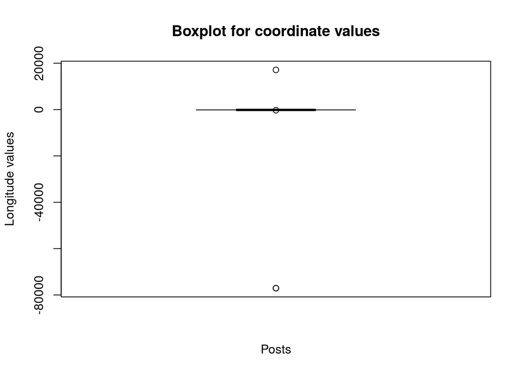

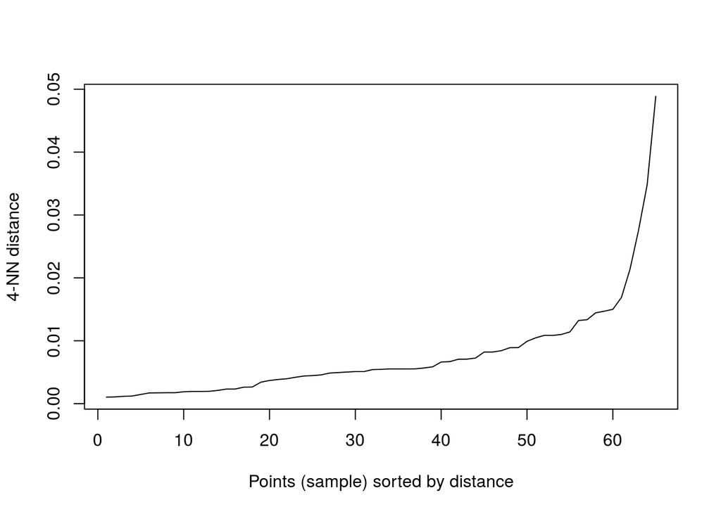

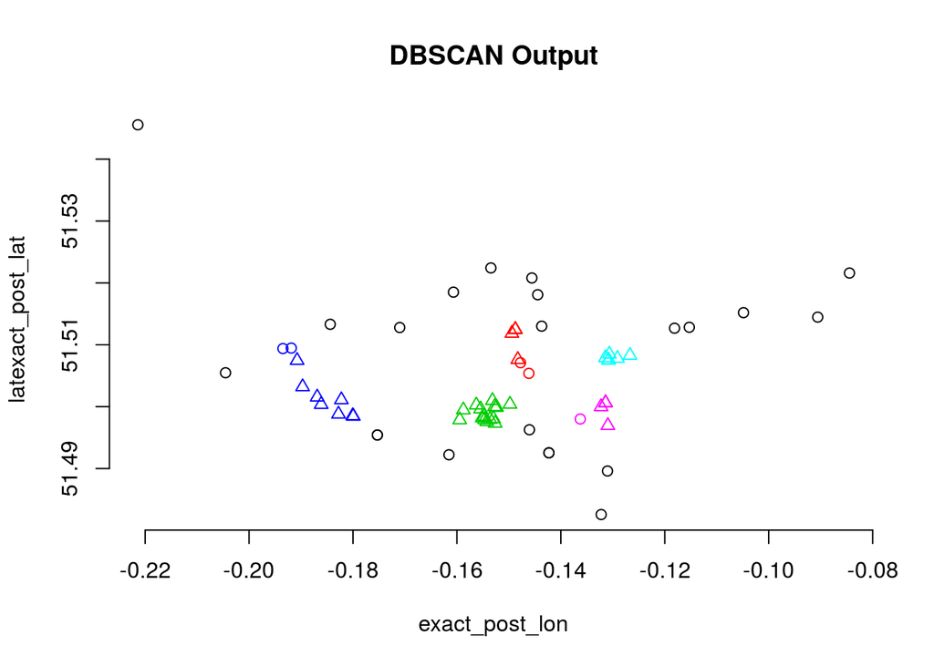

```
## $df_sub
## # A tibble: 69 x 15
##    send_country_iso send_country send_lon send_lat post_country_iso post_country
##    <chr>            <chr>           <dbl>    <dbl> <chr>            <chr>
##  1 ARG              Argentina      -63.6    -38.4  GBR              United King…
##  2 ARG              Argentina      -63.6    -38.4  GBR              United King…
##  3 AUS              Australia      134.     -25.3  GBR              United King…
##  4 AUT              Austria         14.6     47.5  GBR              United King…
##  5 BGD              Bangladesh      90.4     23.7  GBR              United King…
##  6 BEL              Belgium          4.47    50.5  GBR              United King…
##  7 BRA              Brazil         -51.9    -14.2  GBR              United King…
##  8 BRA              Brazil         -51.9    -14.2  GBR              United King…
##  9 BRA              Brazil         -51.9    -14.2  GBR              United King…
## 10 BRN              Brunei Daru…   115.       4.54 GBR              United King…
## # … with 59 more rows, and 9 more variables: post_city_country <chr>,
## #   post_city <chr>, post_city_lon <dbl>, post_city_lat <dbl>, post_type <chr>,
## #   post_title <chr>, full_geo_query <chr>, exact_post_lon <dbl>,
## #   latexact_post_lat <dbl>
##
## $map
##
## $box_plot
## $box_plot$stats
##           [,1]
## [1,] -221.3979
## [2,] -175.3080
## [3,] -152.6486
## [4,] -132.2606
## [5,]  -84.4548
##
## $box_plot$n
## [1] 69
##
## $box_plot$conf
##           [,1]
## [1,] -160.8366
## [2,] -144.4606
##
## $box_plot$out
## [1] -77058.6856   -289.2243 -77049.1660  17107.9724
```

[output cut: 16 more lines]

```
##    <chr>            <chr>           <dbl>    <dbl> <chr>            <chr>
##  1 ARG              Argentina      -63.6    -38.4  GBR              United King…
##  2 ARG              Argentina      -63.6    -38.4  GBR              United King…
##  3 AUS              Australia      134.     -25.3  GBR              United King…
##  4 AUT              Austria         14.6     47.5  GBR              United King…
##  5 BGD              Bangladesh      90.4     23.7  GBR              United King…
##  6 BEL              Belgium          4.47    50.5  GBR              United King…
##  7 BRA              Brazil         -51.9    -14.2  GBR              United King…
##  8 BRA              Brazil         -51.9    -14.2  GBR              United King…
##  9 BRA              Brazil         -51.9    -14.2  GBR              United King…
## 10 BRN              Brunei Daru…   115.       4.54 GBR              United King…
## # … with 55 more rows, and 9 more variables: post_city_country <chr>,
## #   post_city <chr>, post_city_lon <dbl>, post_city_lat <dbl>, post_type <chr>,
## #   post_title <chr>, full_geo_query <chr>, exact_post_lon <dbl>,
## #   latexact_post_lat <dbl>
```

```r
f_exact_city_cluster(p_city_filter = "London",p_df = geo_lowy_no_NA,p_eps = 0.005,p_k =4,p_outlier_remove = TRUE)
```

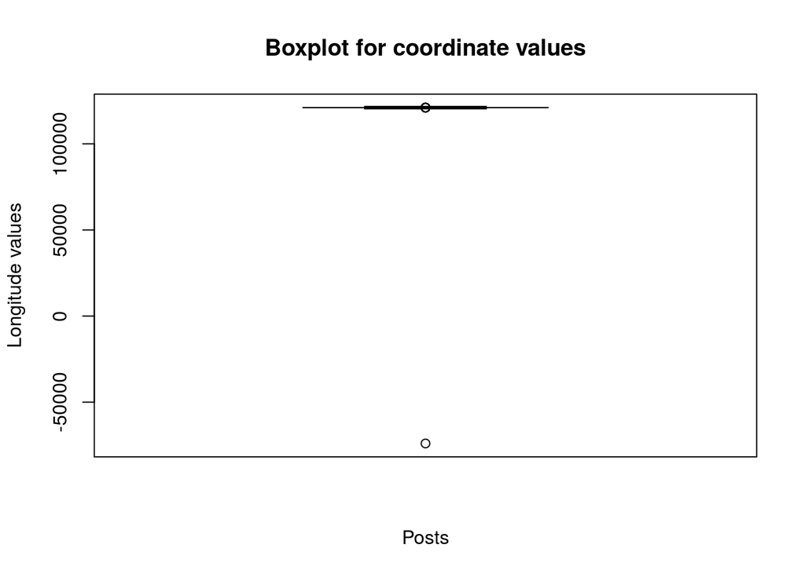

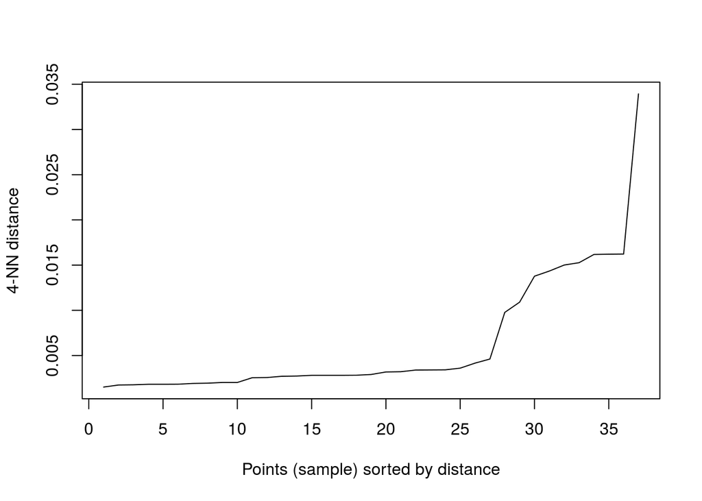

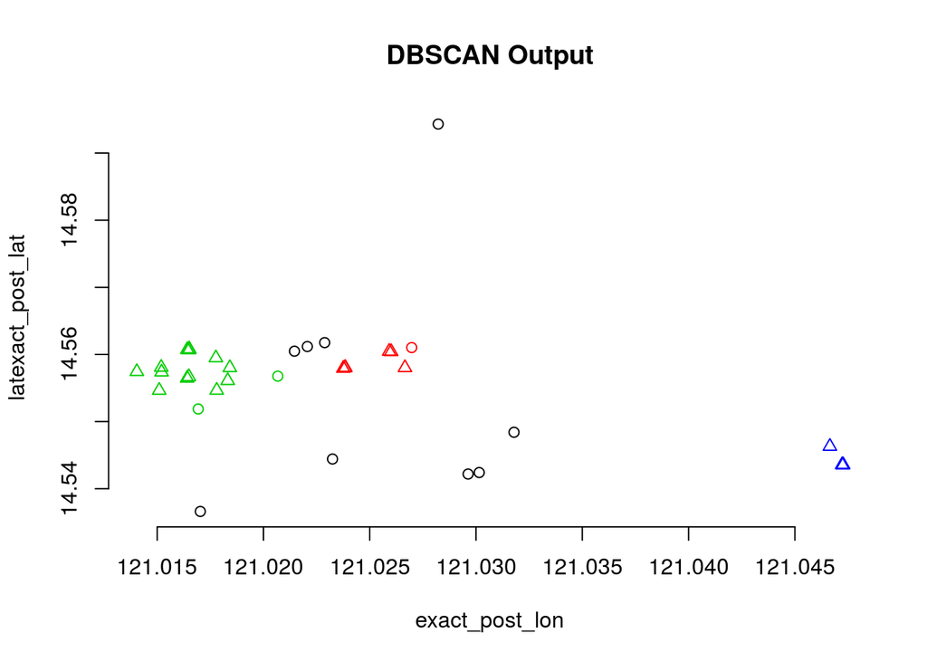

```
## $df_sub
## # A tibble: 46 x 15
##    send_country_iso send_country send_lon send_lat post_country_iso post_country
##    <chr>            <chr>           <dbl>    <dbl> <chr>            <chr>
##  1 ARG              Argentina      -63.6    -38.4  PHL              Philippines
##  2 AUS              Australia      134.     -25.3  PHL              Philippines
##  3 AUT              Austria         14.6     47.5  PHL              Philippines
##  4 BGD              Bangladesh      90.4     23.7  PHL              Philippines
##  5 BEL              Belgium          4.47    50.5  PHL              Philippines
##  6 BRA              Brazil         -51.9    -14.2  PHL              Philippines
##  7 BRN              Brunei Daru…   115.       4.54 PHL              Philippines
##  8 KHM              Cambodia       105.      12.6  PHL              Philippines
##  9 CAN              Canada        -106.      56.1  PHL              Philippines
## 10 CHL              Chile          -71.5    -35.7  PHL              Philippines
## # … with 36 more rows, and 9 more variables: post_city_country <chr>,
## #   post_city <chr>, post_city_lon <dbl>, post_city_lat <dbl>, post_type <chr>,
## #   post_title <chr>, full_geo_query <chr>, exact_post_lon <dbl>,
## #   latexact_post_lat <dbl>
##
## $map
##
## $box_plot
## $box_plot$stats
##          [,1]
## [1,] 121014.0
## [2,] 121016.5
## [3,] 121022.5
## [4,] 121029.6
## [5,] 121047.3
##
## $box_plot$n
## [1] 46
##
## $box_plot$conf
##          [,1]
## [1,] 121019.4
## [2,] 121025.5
##
## $box_plot$out
## [1] 121056.23 121056.64 121057.29 120992.66 121054.84 -73980.17 121053.95
```

[output cut: 17 more lines]

```
##    <chr>            <chr>           <dbl>    <dbl> <chr>            <chr>
##  1 ARG              Argentina      -63.6    -38.4  PHL              Philippines
##  2 AUS              Australia      134.     -25.3  PHL              Philippines
##  3 BGD              Bangladesh      90.4     23.7  PHL              Philippines
##  4 BEL              Belgium          4.47    50.5  PHL              Philippines
##  5 BRA              Brazil         -51.9    -14.2  PHL              Philippines
##  6 BRN              Brunei Daru…   115.       4.54 PHL              Philippines
##  7 KHM              Cambodia       105.      12.6  PHL              Philippines
##  8 CAN              Canada        -106.      56.1  PHL              Philippines
##  9 CHL              Chile          -71.5    -35.7  PHL              Philippines
## 10 CHN              China          104.      35.9  PHL              Philippines
## # … with 27 more rows, and 9 more variables: post_city_country <chr>,
## #   post_city <chr>, post_city_lon <dbl>, post_city_lat <dbl>, post_type <chr>,
## #   post_title <chr>, full_geo_query <chr>, exact_post_lon <dbl>,
## #   latexact_post_lat <dbl>
```

```r
f_exact_city_cluster(p_city_filter = "Manila",p_df = geo_lowy_no_NA,p_eps = 0.003,p_k =4,p_outlier_remove = TRUE)
```

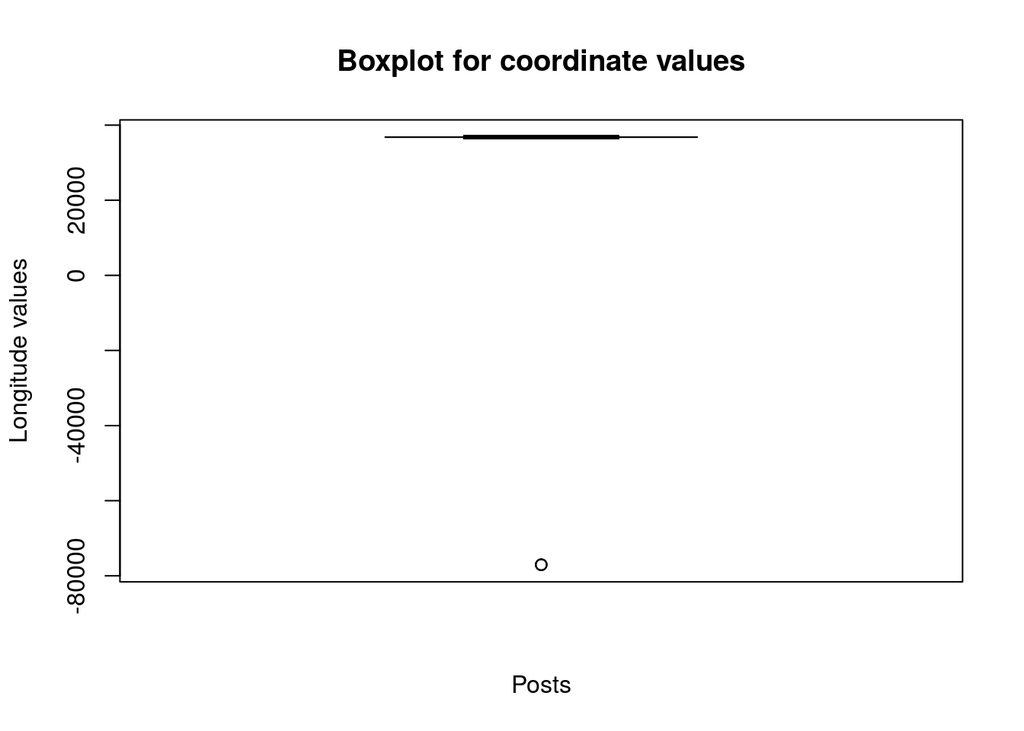

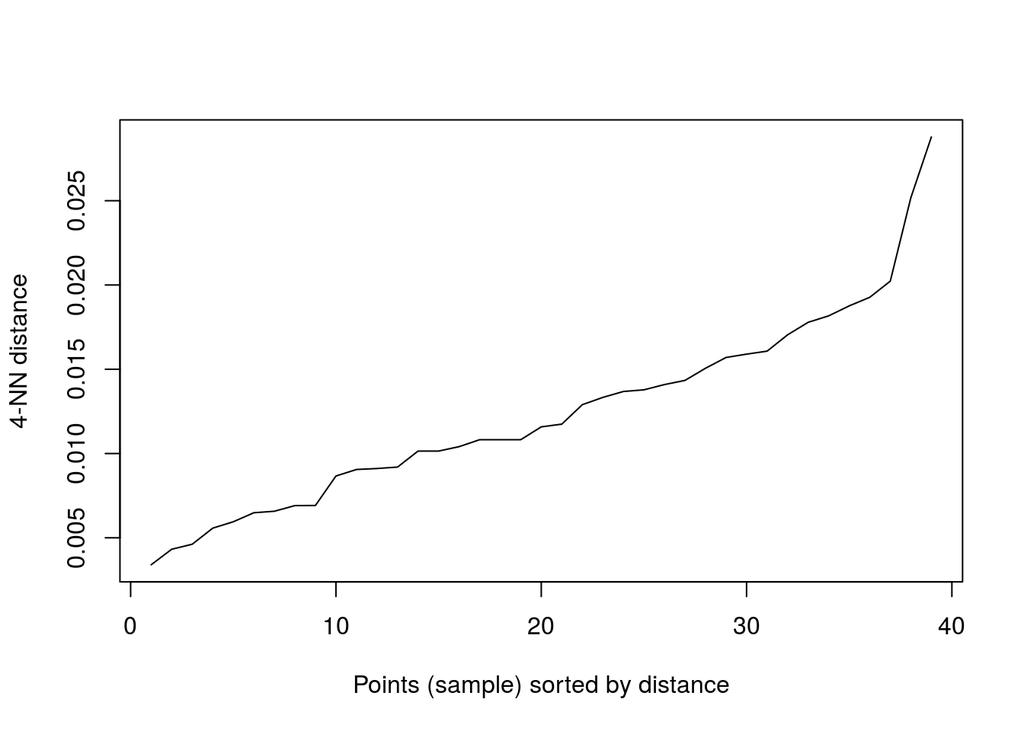

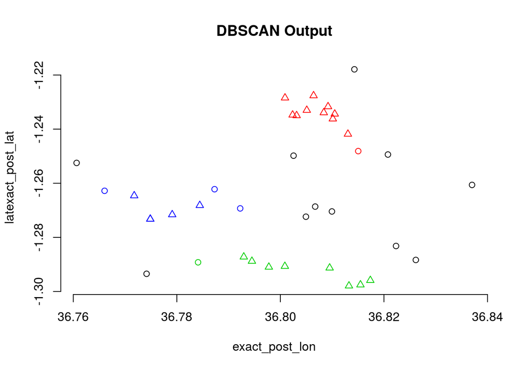

```
## $df_sub
## # A tibble: 42 x 15
##    send_country_iso send_country send_lon send_lat post_country_iso post_country
##    <chr>            <chr>           <dbl>    <dbl> <chr>            <chr>
##  1 ARG              Argentina      -63.6     -38.4 KEN              Kenya
##  2 AUS              Australia      134.      -25.3 KEN              Kenya
##  3 AUT              Austria         14.6      47.5 KEN              Kenya
##  4 BGD              Bangladesh      90.4      23.7 KEN              Kenya
##  5 BEL              Belgium          4.47     50.5 KEN              Kenya
##  6 BRA              Brazil         -51.9     -14.2 KEN              Kenya
##  7 CAN              Canada        -106.       56.1 KEN              Kenya
##  8 CHL              Chile          -71.5     -35.7 KEN              Kenya
##  9 CHN              China          104.       35.9 KEN              Kenya
## 10 CZE              Czech Repub…    15.5      49.8 KEN              Kenya
## # … with 32 more rows, and 9 more variables: post_city_country <chr>,
## #   post_city <chr>, post_city_lon <dbl>, post_city_lat <dbl>, post_type <chr>,
## #   post_title <chr>, full_geo_query <chr>, exact_post_lon <dbl>,
## #   latexact_post_lat <dbl>
##
## $map
##
## $box_plot
## $box_plot$stats
##          [,1]
## [1,] 36760.65
## [2,] 36784.10
## [3,] 36802.84
## [4,] 36810.49
## [5,] 36837.01
##
## $box_plot$n
## [1] 42
##
## $box_plot$conf
##          [,1]
## [1,] 36796.41
## [2,] 36809.27
##
## $box_plot$out
## [1] -77039.89 -77046.28 -77056.01
```

[output cut: 16 more lines]

```
##    <chr>            <chr>           <dbl>    <dbl> <chr>            <chr>
##  1 ARG              Argentina      -63.6     -38.4 KEN              Kenya
##  2 AUS              Australia      134.      -25.3 KEN              Kenya
##  3 AUT              Austria         14.6      47.5 KEN              Kenya
##  4 BGD              Bangladesh      90.4      23.7 KEN              Kenya
##  5 BEL              Belgium          4.47     50.5 KEN              Kenya
##  6 BRA              Brazil         -51.9     -14.2 KEN              Kenya
##  7 CAN              Canada        -106.       56.1 KEN              Kenya
##  8 CHN              China          104.       35.9 KEN              Kenya
##  9 CZE              Czech Repub…    15.5      49.8 KEN              Kenya
## 10 DNK              Denmark          9.50     56.3 KEN              Kenya
## # … with 29 more rows, and 9 more variables: post_city_country <chr>,
## #   post_city <chr>, post_city_lon <dbl>, post_city_lat <dbl>, post_type <chr>,
## #   post_title <chr>, full_geo_query <chr>, exact_post_lon <dbl>,
## #   latexact_post_lat <dbl>
```

```r
f_exact_city_cluster(p_city_filter = "Nairobi",p_df = geo_lowy_no_NA,p_eps = 0.010,p_k =4,p_outlier_remove = TRUE)
```

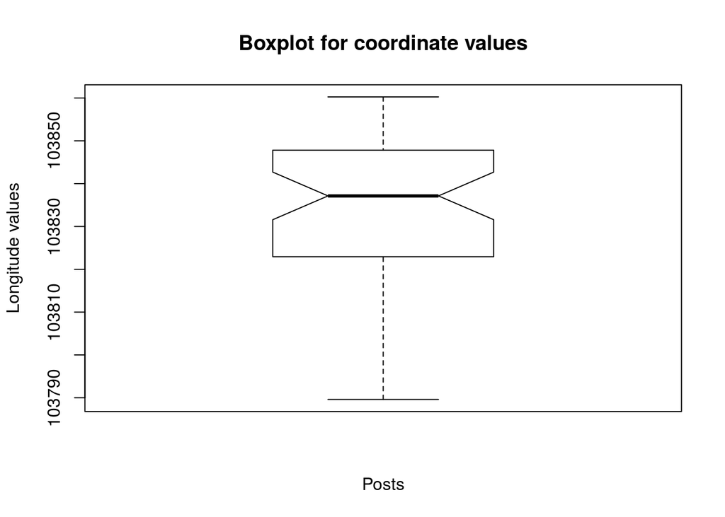

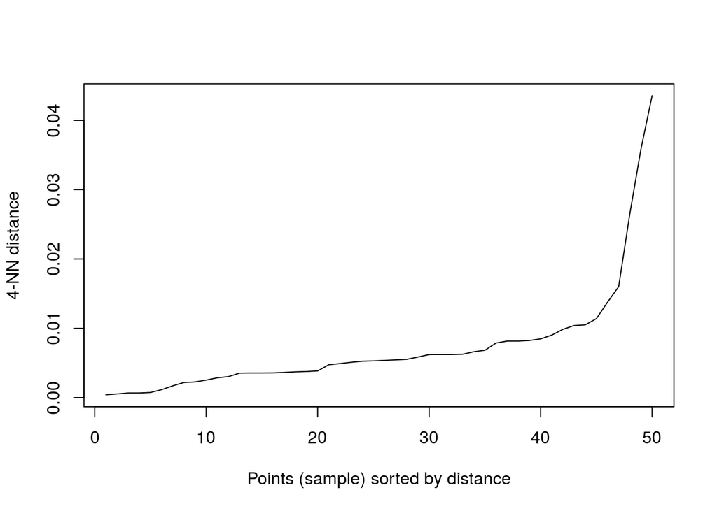

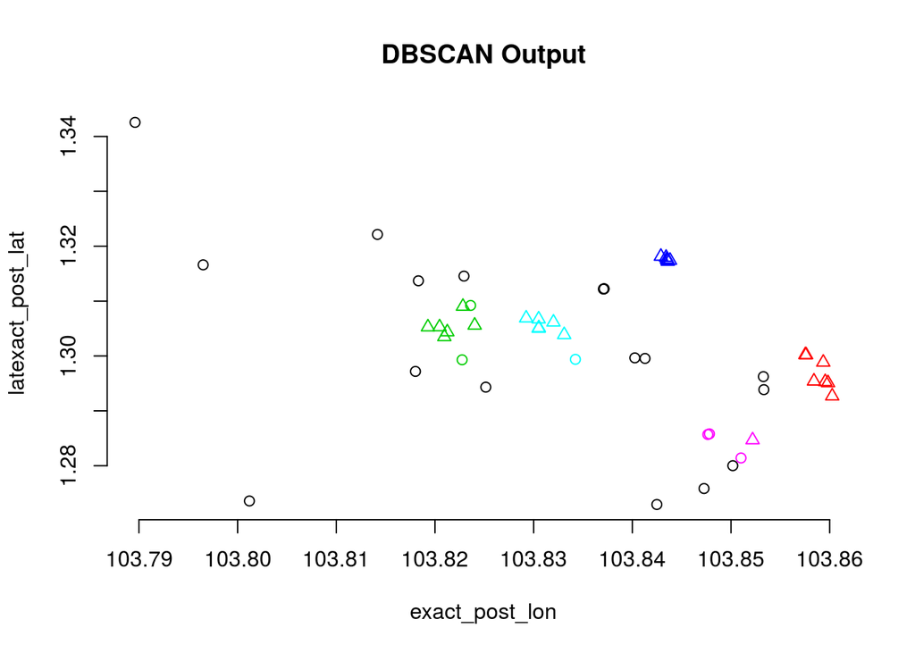

```
## $df_sub
## # A tibble: 50 x 15
##    send_country_iso send_country send_lon send_lat post_country_iso post_country
##    <chr>            <chr>           <dbl>    <dbl> <chr>            <chr>
##  1 ARG              Argentina      -63.6    -38.4  SGP              Singapore
##  2 AUS              Australia      134.     -25.3  SGP              Singapore
##  3 AUT              Austria         14.6     47.5  SGP              Singapore
##  4 BGD              Bangladesh      90.4     23.7  SGP              Singapore
##  5 BEL              Belgium          4.47    50.5  SGP              Singapore
##  6 BRA              Brazil         -51.9    -14.2  SGP              Singapore
##  7 BRN              Brunei Daru…   115.       4.54 SGP              Singapore
##  8 KHM              Cambodia       105.      12.6  SGP              Singapore
##  9 CAN              Canada        -106.      56.1  SGP              Singapore
## 10 CHL              Chile          -71.5    -35.7  SGP              Singapore
## # … with 40 more rows, and 9 more variables: post_city_country <chr>,
## #   post_city <chr>, post_city_lon <dbl>, post_city_lat <dbl>, post_type <chr>,
## #   post_title <chr>, full_geo_query <chr>, exact_post_lon <dbl>,
## #   latexact_post_lat <dbl>
##
## $map
##
## $box_plot
## $box_plot$stats
##          [,1]
## [1,] 103789.6
## [2,] 103822.9
## [3,] 103837.1
## [4,] 103847.8
## [5,] 103860.3
##
## $box_plot$n
## [1] 50
##
## $box_plot$conf
##          [,1]
## [1,] 103831.6
## [2,] 103842.7
##
## $box_plot$out
## numeric(0)
```

[output cut: 16 more lines]

```
##    <chr>            <chr>           <dbl>    <dbl> <chr>            <chr>
##  1 ARG              Argentina      -63.6    -38.4  SGP              Singapore
##  2 AUS              Australia      134.     -25.3  SGP              Singapore
##  3 AUT              Austria         14.6     47.5  SGP              Singapore
##  4 BGD              Bangladesh      90.4     23.7  SGP              Singapore
##  5 BEL              Belgium          4.47    50.5  SGP              Singapore
##  6 BRA              Brazil         -51.9    -14.2  SGP              Singapore
##  7 BRN              Brunei Daru…   115.       4.54 SGP              Singapore
##  8 KHM              Cambodia       105.      12.6  SGP              Singapore
##  9 CAN              Canada        -106.      56.1  SGP              Singapore
## 10 CHL              Chile          -71.5    -35.7  SGP              Singapore
## # … with 40 more rows, and 9 more variables: post_city_country <chr>,
## #   post_city <chr>, post_city_lon <dbl>, post_city_lat <dbl>, post_type <chr>,
## #   post_title <chr>, full_geo_query <chr>, exact_post_lon <dbl>,
## #   latexact_post_lat <dbl>
```

```r
f_exact_city_cluster(p_city_filter = "Singapore",p_df = geo_lowy_no_NA,p_eps = 0.005,p_k =4,p_outlier_remove = TRUE)
```

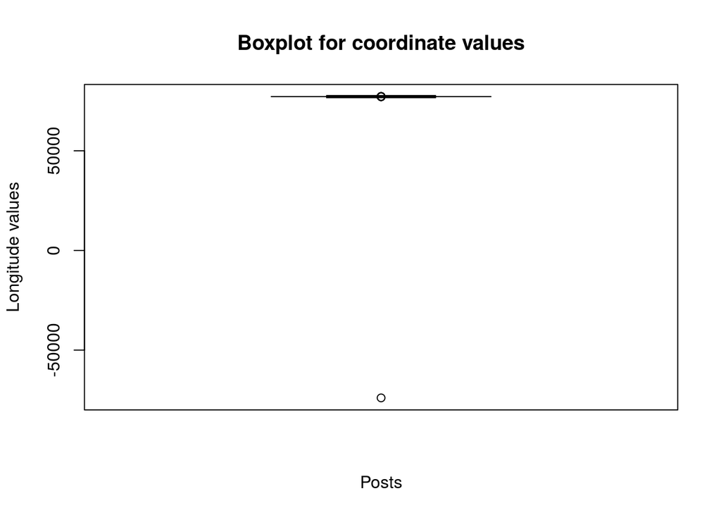

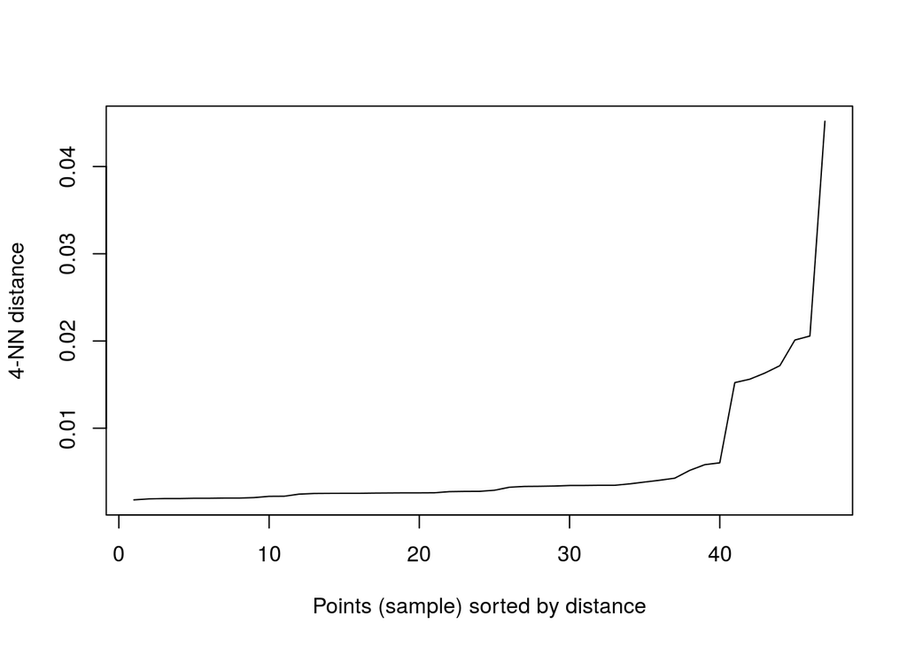

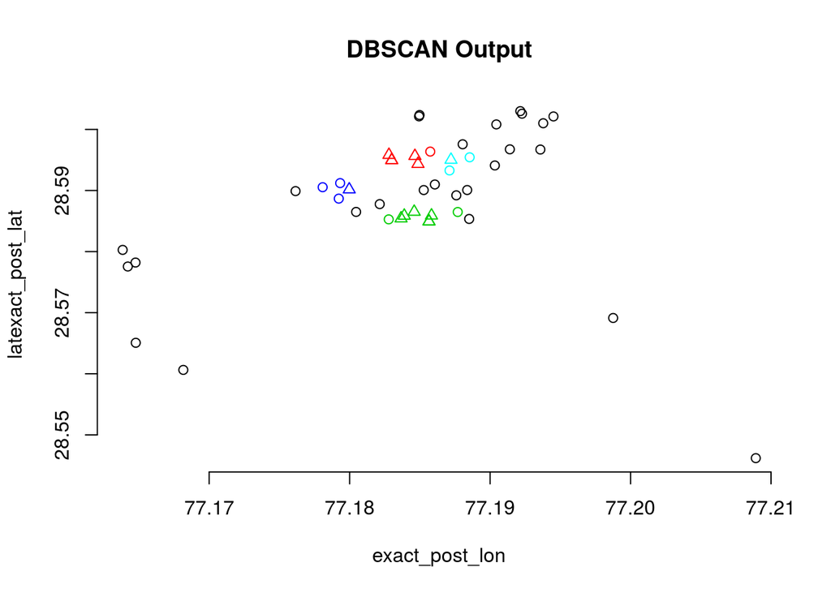

```
## $df_sub
## # A tibble: 60 x 15
##    send_country_iso send_country send_lon send_lat post_country_iso post_country
##    <chr>            <chr>           <dbl>    <dbl> <chr>            <chr>
##  1 ARG              Argentina      -63.6    -38.4  IND              India
##  2 AUS              Australia      134.     -25.3  IND              India
##  3 AUT              Austria         14.6     47.5  IND              India
##  4 BGD              Bangladesh      90.4     23.7  IND              India
##  5 BEL              Belgium          4.47    50.5  IND              India
##  6 BTN              Bhutan          90.4     27.5  IND              India
##  7 BRA              Brazil         -51.9    -14.2  IND              India
##  8 BRN              Brunei Daru…   115.       4.54 IND              India
##  9 KHM              Cambodia       105.      12.6  IND              India
## 10 CAN              Canada        -106.      56.1  IND              India
## # … with 50 more rows, and 9 more variables: post_city_country <chr>,
## #   post_city <chr>, post_city_lon <dbl>, post_city_lat <dbl>, post_type <chr>,
## #   post_title <chr>, full_geo_query <chr>, exact_post_lon <dbl>,
## #   latexact_post_lat <dbl>
##
## $map
##
## $box_plot
## $box_plot$stats
##          [,1]
## [1,] 77163.84
## [2,] 77180.22
## [3,] 77185.65
## [4,] 77191.78
## [5,] 77208.92
##
## $box_plot$n
## [1] 60
##
## $box_plot$conf
##          [,1]
## [1,] 77183.29
## [2,] 77188.01
##
## $box_plot$out
##  [1]  77160.95  77219.47  77159.91  77221.46  77240.89  77243.48  77214.72
```

[output cut: 17 more lines]

```
##    <chr>            <chr>           <dbl>    <dbl> <chr>            <chr>
##  1 AUS              Australia      134.     -25.3  IND              India
##  2 AUT              Austria         14.6     47.5  IND              India
##  3 BGD              Bangladesh      90.4     23.7  IND              India
##  4 BEL              Belgium          4.47    50.5  IND              India
##  5 BTN              Bhutan          90.4     27.5  IND              India
##  6 BRN              Brunei Daru…   115.       4.54 IND              India
##  7 KHM              Cambodia       105.      12.6  IND              India
##  8 CAN              Canada        -106.      56.1  IND              India
##  9 CHL              Chile          -71.5    -35.7  IND              India
## 10 CHN              China          104.      35.9  IND              India
## # … with 37 more rows, and 9 more variables: post_city_country <chr>,
## #   post_city <chr>, post_city_lon <dbl>, post_city_lat <dbl>, post_type <chr>,
## #   post_title <chr>, full_geo_query <chr>, exact_post_lon <dbl>,
## #   latexact_post_lat <dbl>
```

```r
f_exact_city_cluster(p_city_filter = "New Delhi",p_df = geo_lowy_no_NA,p_eps = 0.002,p_k =4,p_outlier_remove = TRUE)
```

#### REFERENCE CODE FUNCTIONS

**`f_exact_city_postings()`**:

```
###FUNCTION REFERENCE FOR CODE
###FUNCTION
f_exact_city_postings <- function(p_city_filter,p_df){

  ###Subset of dataframe for chosen country
  sub_city_df <- p_df[p_df$post_city == p_city_filter,]

  #create spatial objects
  sub_city_sf <-
    st_as_sf(sub_city_df,coords=c("post_city_lon","post_city_lat"),crs = 4326)

  sub_city_geo_sf <-
    st_as_sf(sub_city_df,coords=c("exact_post_lon","exact_post_lat"),crs = 4326)

  #City lat longs
  exact_map <- mapview(
      #spatial object
      sub_city_sf,
      legend = FALSE,
      layer.name = "City coordinates",
      alpha.regions = 0.4,
      label = sub_city_sf$post_city_country,
      cex = 10

      #Exact lat longs
      )+ mapview(
      #spatial object
      sub_city_geo_sf,
      legend = FALSE,
      layer.name = "Geocoded exact coordinates",
      label = sub_city_geo_sf$full_geo_query,
      color = "red",
      alpha.regions = 0.4,
      col.regions = "red",
      cex = 0.1)

  mapshot(exact_map, url = paste("/cloud/project/Data/MapFiles/",p_city_filter,"map.html",sep="_"))

  #return dl table,map
  return_list <- list(df = sub_city_df,map = exact_map)
  return(return_list)
}
```